# Linear Regression using Python

### Topics to Discuss:

```python
import pandas as pd
import numpy as np
```

### Adverstiment Dataset

> The adverstiting dataset captures sales revenue generated with respect to advertisement spends across multiple channles like radio, tv and newspaper.

### Attribution Descriptions

> TV - Spend on TV Advertisements  
> Radio - Spend on radio Advertisements  
> Newspaper - Spend on newspaper Advertisements  
> Sales - Sales revenue generated  
> Note: The amounts are in diffrent units

```python
# load the data set
advt = pd.read_csv( "Advertising.csv" )
```

```python
advt.head(5)
```

|  | Unnamed: 0 | TV | Radio | Newspaper | Sales |
| --- | --- | --- | --- | --- | --- |
| 0 | 1 | 230.1 | 37.8 | 69.2 | 22.1 |
| 1 | 2 | 44.5 | 39.3 | 45.1 | 10.4 |
| 2 | 3 | 17.2 | 45.9 | 69.3 | 9.3 |
| 3 | 4 | 151.5 | 41.3 | 58.5 | 18.5 |
| 4 | 5 | 180.8 | 10.8 | 58.4 | 12.9 |

```python
import pandas_profiling
```

Overview

Dataset info

| Number of variables | 5 |
| --- | --- |
| Number of observations | 200 |
| Total Missing (%) | 0.0% |
| Total size in memory | 7.9 KiB |
| Average record size in memory | 40.4 B |

Variables types

| Numeric | 5 |
| --- | --- |
| Categorical | 0 |
| Date | 0 |
| Text (Unique) | 0 |
| Rejected | 0 |

Warnings

Variables

Newspaper  
Numeric

| Distinct count | 172 |
| --- | --- |
| Unique (%) | 86.0% |
| Missing (%) | 0.0% |
| Missing (n) | 0 |
| Infinite (%) | 0.0% |
| Infinite (n) | 0 |

| Mean | 30.554 |
| --- | --- |
| Minimum | 0.3 |
| Maximum | 114 |
| Zeros (%) | 0.0% |

Toggle details

**Statistics**

Quantile statistics

| Minimum | 0.3 |
| --- | --- |
| 5-th percentile | 3.6 |
| Q1 | 12.75 |
| Median | 25.75 |
| Q3 | 45.1 |
| 95-th percentile | 71.825 |
| Maximum | 114 |
| Range | 113.7 |
| Interquartile range | 32.35 |

Descriptive statistics

| Standard deviation | 21.779 |
| --- | --- |
| Coef of variation | 0.71279 |
| Kurtosis | 0.6495 |
| Mean | 30.554 |
| MAD | 17.635 |
| Skewness | 0.89472 |
| Sum | 6110.8 |
| Variance | 474.31 |
| Memory size | 1.6 KiB |

**Histogram**

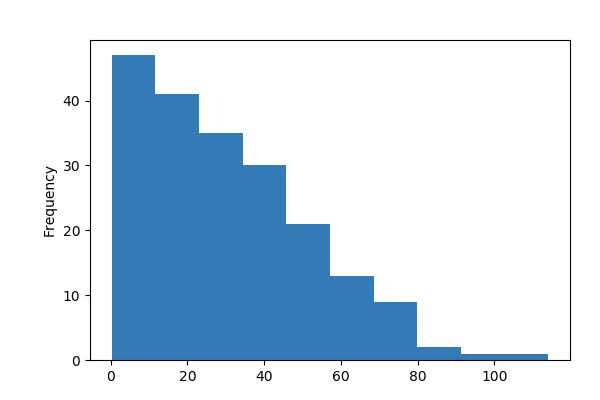

**Common Values**

| Value | Count | Frequency (%) |  |
| --- | --- | --- | --- |
| 8.7 | 3 | 1.5% |  |
| 25.6 | 3 | 1.5% |  |
| 9.3 | 3 | 1.5% |  |
| 14.2 | 2 | 1.0% |  |
| 45.1 | 2 | 1.0% |  |
| 18.3 | 2 | 1.0% |  |
| 59.0 | 2 | 1.0% |  |
| 52.9 | 2 | 1.0% |  |
| 22.3 | 2 | 1.0% |  |
| 34.6 | 2 | 1.0% |  |
| Other values (162) | 177 | 88.5% |  |

**Extreme Values**

Minimum 5 values

| Value | Count | Frequency (%) |  |
| --- | --- | --- | --- |
| 0.3 | 1 | 0.5% |  |
| 0.9 | 1 | 0.5% |  |
| 1.0 | 1 | 0.5% |  |
| 1.7 | 1 | 0.5% |  |
| 1.8 | 1 | 0.5% |  |

Maximum 5 values

| Value | Count | Frequency (%) |  |
| --- | --- | --- | --- |
| 79.2 | 1 | 0.5% |  |
| 84.8 | 1 | 0.5% |  |
| 89.4 | 1 | 0.5% |  |
| 100.9 | 1 | 0.5% |  |
| 114.0 | 1 | 0.5% |  |

Radio  
Numeric

| Distinct count | 167 |
| --- | --- |
| Unique (%) | 83.5% |
| Missing (%) | 0.0% |
| Missing (n) | 0 |
| Infinite (%) | 0.0% |
| Infinite (n) | 0 |

| Mean | 23.264 |
| --- | --- |
| Minimum | 0 |
| Maximum | 49.6 |
| Zeros (%) | 0.5% |

Toggle details

**Statistics**

Quantile statistics

| Minimum | 0 |
| --- | --- |
| 5-th percentile | 1.995 |
| Q1 | 9.975 |
| Median | 22.9 |
| Q3 | 36.525 |
| 95-th percentile | 46.81 |
| Maximum | 49.6 |
| Range | 49.6 |
| Interquartile range | 26.55 |

Descriptive statistics

| Standard deviation | 14.847 |
| --- | --- |
| Coef of variation | 0.63819 |
| Kurtosis | -1.2604 |
| Mean | 23.264 |
| MAD | 12.969 |
| Skewness | 0.094175 |
| Sum | 4652.8 |
| Variance | 220.43 |
| Memory size | 1.6 KiB |

**Histogram**

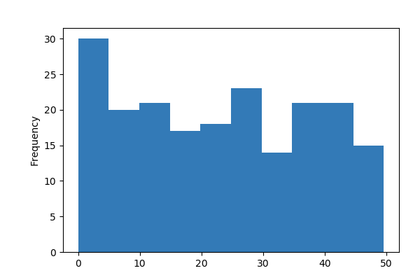

**Common Values**

| Value | Count | Frequency (%) |  |
| --- | --- | --- | --- |
| 5.7 | 3 | 1.5% |  |
| 4.1 | 3 | 1.5% |  |
| 26.7 | 2 | 1.0% |  |
| 18.1 | 2 | 1.0% |  |
| 43.0 | 2 | 1.0% |  |
| 10.8 | 2 | 1.0% |  |
| 24.6 | 2 | 1.0% |  |
| 49.4 | 2 | 1.0% |  |
| 48.9 | 2 | 1.0% |  |
| 33.5 | 2 | 1.0% |  |
| Other values (157) | 178 | 89.0% |  |

**Extreme Values**

Minimum 5 values

| Value | Count | Frequency (%) |  |
| --- | --- | --- | --- |
| 0.0 | 1 | 0.5% |  |
| 0.3 | 1 | 0.5% |  |
| 0.4 | 1 | 0.5% |  |
| 0.8 | 1 | 0.5% |  |
| 1.3 | 1 | 0.5% |  |

Maximum 5 values

| Value | Count | Frequency (%) |  |
| --- | --- | --- | --- |
| 47.8 | 1 | 0.5% |  |
| 48.9 | 2 | 1.0% |  |
| 49.0 | 2 | 1.0% |  |
| 49.4 | 2 | 1.0% |  |
| 49.6 | 1 | 0.5% |  |

Sales  
Numeric

| Distinct count | 121 |
| --- | --- |
| Unique (%) | 60.5% |
| Missing (%) | 0.0% |
| Missing (n) | 0 |
| Infinite (%) | 0.0% |
| Infinite (n) | 0 |

| Mean | 14.023 |
| --- | --- |
| Minimum | 1.6 |
| Maximum | 27 |
| Zeros (%) | 0.0% |

Toggle details

**Statistics**

Quantile statistics

| Minimum | 1.6 |
| --- | --- |
| 5-th percentile | 6.6 |
| Q1 | 10.375 |
| Median | 12.9 |
| Q3 | 17.4 |
| 95-th percentile | 23.8 |
| Maximum | 27 |
| Range | 25.4 |
| Interquartile range | 7.025 |

Descriptive statistics

| Standard deviation | 5.2175 |
| --- | --- |
| Coef of variation | 0.37208 |
| Kurtosis | -0.40887 |
| Mean | 14.023 |
| MAD | 4.28 |
| Skewness | 0.40757 |
| Sum | 2804.5 |
| Variance | 27.222 |
| Memory size | 1.6 KiB |

**Histogram**

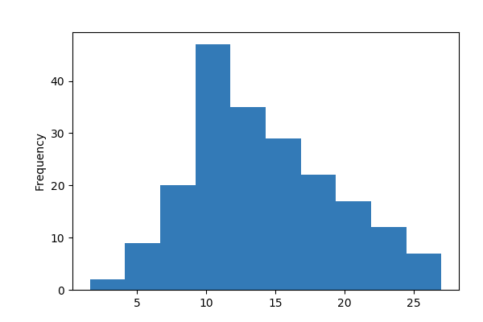

**Common Values**

| Value | Count | Frequency (%) |  |
| --- | --- | --- | --- |
| 9.7 | 5 | 2.5% |  |
| 12.9 | 4 | 2.0% |  |
| 11.7 | 4 | 2.0% |  |
| 15.9 | 4 | 2.0% |  |
| 25.4 | 3 | 1.5% |  |
| 13.4 | 3 | 1.5% |  |
| 10.6 | 3 | 1.5% |  |
| 13.2 | 3 | 1.5% |  |
| 10.1 | 3 | 1.5% |  |
| 20.7 | 3 | 1.5% |  |
| Other values (111) | 165 | 82.5% |  |

**Extreme Values**

Minimum 5 values

| Value | Count | Frequency (%) |  |
| --- | --- | --- | --- |
| 1.6 | 1 | 0.5% |  |
| 3.2 | 1 | 0.5% |  |
| 4.8 | 1 | 0.5% |  |
| 5.3 | 2 | 1.0% |  |
| 5.5 | 1 | 0.5% |  |

Maximum 5 values

| Value | Count | Frequency (%) |  |
| --- | --- | --- | --- |
| 24.7 | 1 | 0.5% |  |
| 25.4 | 3 | 1.5% |  |
| 25.5 | 1 | 0.5% |  |
| 26.2 | 1 | 0.5% |  |
| 27.0 | 1 | 0.5% |  |

TV  
Numeric

| Distinct count | 190 |
| --- | --- |
| Unique (%) | 95.0% |
| Missing (%) | 0.0% |
| Missing (n) | 0 |
| Infinite (%) | 0.0% |
| Infinite (n) | 0 |

| Mean | 147.04 |
| --- | --- |
| Minimum | 0.7 |
| Maximum | 296.4 |
| Zeros (%) | 0.0% |

Toggle details

**Statistics**

Quantile statistics

| Minimum | 0.7 |
| --- | --- |
| 5-th percentile | 13.195 |
| Q1 | 74.375 |
| Median | 149.75 |
| Q3 | 218.82 |
| 95-th percentile | 280.74 |
| Maximum | 296.4 |
| Range | 295.7 |
| Interquartile range | 144.45 |

Descriptive statistics

| Standard deviation | 85.854 |
| --- | --- |
| Coef of variation | 0.58387 |
| Kurtosis | -1.2265 |
| Mean | 147.04 |
| MAD | 75.105 |
| Skewness | -0.069853 |
| Sum | 29408 |
| Variance | 7370.9 |
| Memory size | 1.6 KiB |

**Histogram**

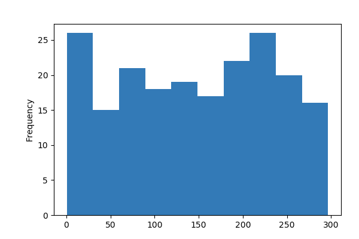

**Common Values**

| Value | Count | Frequency (%) |  |
| --- | --- | --- | --- |
| 197.6 | 2 | 1.0% |  |
| 237.4 | 2 | 1.0% |  |
| 177.0 | 2 | 1.0% |  |
| 76.4 | 2 | 1.0% |  |
| 222.4 | 2 | 1.0% |  |
| 17.2 | 2 | 1.0% |  |
| 240.1 | 2 | 1.0% |  |
| 184.9 | 2 | 1.0% |  |
| 109.8 | 2 | 1.0% |  |
| 199.8 | 2 | 1.0% |  |
| Other values (180) | 180 | 90.0% |  |

**Extreme Values**

Minimum 5 values

| Value | Count | Frequency (%) |  |
| --- | --- | --- | --- |
| 0.7 | 1 | 0.5% |  |
| 4.1 | 1 | 0.5% |  |
| 5.4 | 1 | 0.5% |  |
| 7.3 | 1 | 0.5% |  |
| 7.8 | 1 | 0.5% |  |

Maximum 5 values

| Value | Count | Frequency (%) |  |
| --- | --- | --- | --- |
| 289.7 | 1 | 0.5% |  |
| 290.7 | 1 | 0.5% |  |
| 292.9 | 1 | 0.5% |  |
| 293.6 | 1 | 0.5% |  |
| 296.4 | 1 | 0.5% |  |

Unnamed: 0  
Numeric

| Distinct count | 200 |
| --- | --- |
| Unique (%) | 100.0% |
| Missing (%) | 0.0% |
| Missing (n) | 0 |
| Infinite (%) | 0.0% |
| Infinite (n) | 0 |

| Mean | 100.5 |
| --- | --- |
| Minimum | 1 |
| Maximum | 200 |
| Zeros (%) | 0.0% |

Toggle details

**Statistics**

Quantile statistics

| Minimum | 1 |
| --- | --- |
| 5-th percentile | 10.95 |
| Q1 | 50.75 |
| Median | 100.5 |
| Q3 | 150.25 |
| 95-th percentile | 190.05 |
| Maximum | 200 |
| Range | 199 |
| Interquartile range | 99.5 |

Descriptive statistics

| Standard deviation | 57.879 |
| --- | --- |
| Coef of variation | 0.57591 |
| Kurtosis | -1.2 |
| Mean | 100.5 |
| MAD | 50 |
| Skewness | 0 |
| Sum | 20100 |
| Variance | 3350 |
| Memory size | 1.6 KiB |

**Histogram**

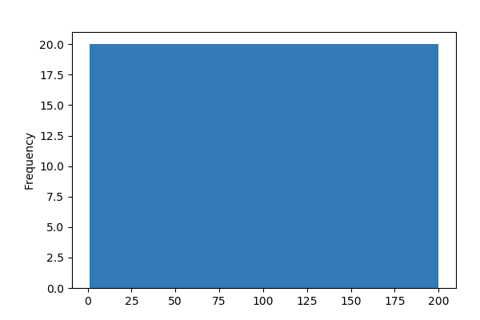

**Common Values**

| Value | Count | Frequency (%) |  |
| --- | --- | --- | --- |
| 200 | 1 | 0.5% |  |
| 63 | 1 | 0.5% |  |
| 73 | 1 | 0.5% |  |
| 72 | 1 | 0.5% |  |
| 71 | 1 | 0.5% |  |
| 70 | 1 | 0.5% |  |
| 69 | 1 | 0.5% |  |
| 68 | 1 | 0.5% |  |
| 67 | 1 | 0.5% |  |
| 66 | 1 | 0.5% |  |
| Other values (190) | 190 | 95.0% |  |

**Extreme Values**

Minimum 5 values

| Value | Count | Frequency (%) |  |
| --- | --- | --- | --- |
| 1 | 1 | 0.5% |  |
| 2 | 1 | 0.5% |  |
| 3 | 1 | 0.5% |  |
| 4 | 1 | 0.5% |  |
| 5 | 1 | 0.5% |  |

Maximum 5 values

| Value | Count | Frequency (%) |  |
| --- | --- | --- | --- |
| 196 | 1 | 0.5% |  |
| 197 | 1 | 0.5% |  |
| 198 | 1 | 0.5% |  |
| 199 | 1 | 0.5% |  |
| 200 | 1 | 0.5% |  |

Sample

|  | Unnamed: 0 | TV | Radio | Newspaper | Sales |
| --- | --- | --- | --- | --- | --- |
| 0 | 1 | 230.1 | 37.8 | 69.2 | 22.1 |
| 1 | 2 | 44.5 | 39.3 | 45.1 | 10.4 |
| 2 | 3 | 17.2 | 45.9 | 69.3 | 9.3 |
| 3 | 4 | 151.5 | 41.3 | 58.5 | 18.5 |
| 4 | 5 | 180.8 | 10.8 | 58.4 | 12.9 |

```python
pandas_profiling.ProfileReport(advt)
```

```python
advt.info()
```

```
<class 'pandas.core.frame.DataFrame'>
RangeIndex: 200 entries, 0 to 199
Data columns (total 5 columns):
Unnamed: 0    200 non-null int64
TV            200 non-null float64
Radio         200 non-null float64
Newspaper     200 non-null float64
Sales         200 non-null float64
dtypes: float64(4), int64(1)
memory usage: 7.9 KB
```

```python
#Remove the first column

advt = advt[["TV", "Radio", "Newspaper", "Sales"]]
```

```python
advt.head()
```

[output not shown]

```python
# Creating Data audit Report
# Use a general function that returns multiple values
def var_summary(x):
    return pd.Series([x.count(), x.isnull().sum(), x.sum(), x.mean(), x.median(),  x.std(), x.var(), x.min(), x.quantile(0.01), x.quantile(0.05),x.quantile(0.10),x.quantile(0.25),x.quantile(0.50),x.quantile(0.75), x.quantile(0.90),x.quantile(0.95), x.quantile(0.99),x.max()],
                  index=['N', 'NMISS', 'SUM', 'MEAN','MEDIAN', 'STD', 'VAR', 'MIN', 'P1' , 'P5' ,'P10' ,'P25' ,'P50' ,'P75' ,'P90' ,'P95' ,'P99' ,'MAX'])


advt.apply(lambda x: var_summary(x)).T
```

|  | N | NMISS | SUM | MEAN | MEDIAN | STD | VAR | MIN | P1 | P5 | P10 | P25 | P50 | P75 | P90 | P95 | P99 | MAX |
| --- | --- | --- | --- | --- | --- | --- | --- | --- | --- | --- | --- | --- | --- | --- | --- | --- | --- | --- |
| TV | 200.0 | 0.0 | 29408.5 | 147.0425 | 149.75 | 85.854236 | 7370.949893 | 0.7 | 5.387 | 13.195 | 24.88 | 74.375 | 149.75 | 218.825 | 261.44 | 280.735 | 292.907 | 296.4 |
| Radio | 200.0 | 0.0 | 4652.8 | 23.2640 | 22.90 | 14.846809 | 220.427743 | 0.0 | 0.399 | 1.995 | 3.40 | 9.975 | 22.90 | 36.525 | 43.52 | 46.810 | 49.400 | 49.6 |
| Newspaper | 200.0 | 0.0 | 6110.8 | 30.5540 | 25.75 | 21.778621 | 474.308326 | 0.3 | 0.999 | 3.600 | 5.99 | 12.750 | 25.75 | 45.100 | 59.07 | 71.825 | 89.515 | 114.0 |
| Sales | 200.0 | 0.0 | 2804.5 | 14.0225 | 12.90 | 5.217457 | 27.221853 | 1.6 | 4.784 | 6.600 | 7.96 | 10.375 | 12.90 | 17.400 | 21.71 | 23.800 | 25.507 | 27.0 |

```python
var_summary(advt.TV)
```

```
N           200.000000
NMISS         0.000000
SUM       29408.500000
MEAN        147.042500
MEDIAN      149.750000
STD          85.854236
VAR        7370.949893
MIN           0.700000
P1            5.387000
P5           13.195000
P10          24.880000
P25          74.375000
P50         149.750000
P75         218.825000
P90         261.440000
P95         280.735000
P99         292.907000
MAX         296.400000
dtype: float64
```

```python
#Handling Outliers
advt['Sales']= advt['Sales'].clip_upper(advt['Sales'].quantile(0.99))
advt['Sales']= advt['Sales'].clip_lower(advt['Sales'].quantile(0.01))

advt['Newspaper']= advt['Newspaper'].clip_upper(advt['Newspaper'].quantile(0.99))
advt['Newspaper']= advt['Newspaper'].clip_lower(advt['Newspaper'].quantile(0.01))
```

```python
#Handling Missings
# Fill with mean
advt['Sales']=advt['Sales'].fillna(advt['Sales'].mean())
```

```python
#Dummy variable creation
#print df_G.join(pd.get_dummies(advt['key'], prefix='dummy')).drop('key', axis=1).drop('dummy_c', axis=1)
```

```python
# exploring data
# Distribution of variables
import seaborn as sns
import matplotlib.pyplot as plt
%matplotlib inline
```

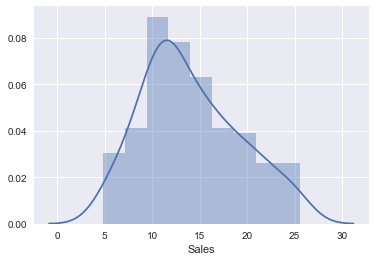

```python
sns.distplot( advt.Sales )
```

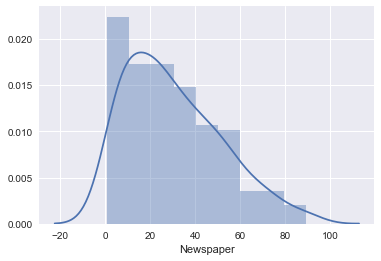

```python
sns.distplot( advt.Newspaper )
```

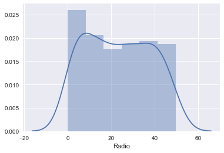

```python
sns.distplot( advt.Radio )
```

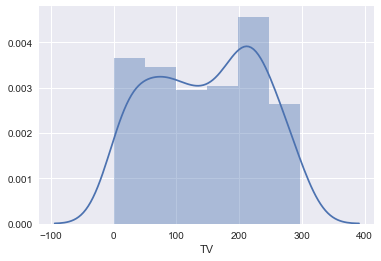

```python
sns.distplot( advt.TV )
```

### Notes:

> Sales seems to be normal distribution. Spending on newspaper advertisement seems to be righ skewed. Most of the spends on newspaper is fairly low where are spend on radio and tv seems be uniform distribution. Spends on tv are comparatively higher then spens on radio and newspaper.

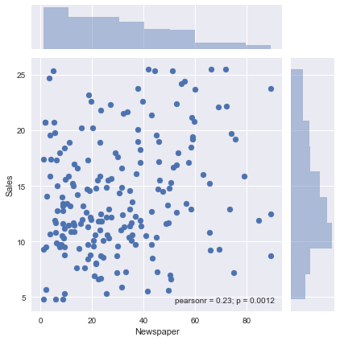

```python
#Is there a relationship between sales and spend various advertising channels?

#Sales Vs. Newspaper advertisement spends

sns.jointplot(  advt.Newspaper, advt.Sales )
```

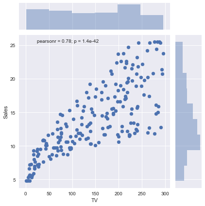

```python
#Sales Vs. TV advertisement spends
sns.jointplot(  advt.TV, advt.Sales )
```

# Notes

> Sales and spend on newpaper is not highly correlaed where are sales and spend on tv is highly correlated.

```python
sns.pairplot?
```

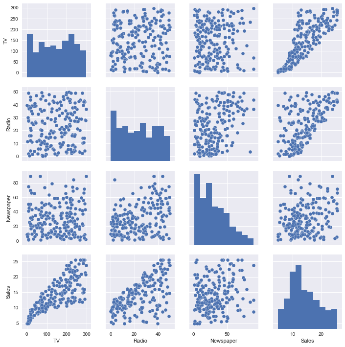

```python
# Visualizing pairwise correleation

sns.pairplot( advt )
```

```python
# Calculating correlations
advt.TV.corr( advt.Sales )
```

```
0.78236819845320438
```

```python
advt.corr()
```

|  | TV | Radio | Newspaper | Sales |
| --- | --- | --- | --- | --- |
| TV | 1.000000 | 0.054809 | 0.059085 | 0.782368 |
| Radio | 0.054809 | 1.000000 | 0.356255 | 0.583363 |
| Newspaper | 0.059085 | 0.356255 | 1.000000 | 0.227594 |
| Sales | 0.782368 | 0.583363 | 0.227594 | 1.000000 |

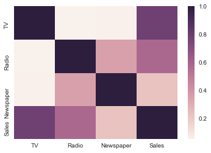

```python
# Visualizing the correlations
#The darker is the color, the stronger is the correlation
sns.heatmap( advt.corr() )
```

### Building Regression Model

> Linear regression is an approach for modeling the relationship between a scalar dependent variable y and one or more explanatory variables (or independent variables) denoted X. The case of one explanatory variable is called simple linear regression. For more than one explanatory variable, the process is called multiple linear regression  
> A simple linear regression model is given by Y=mX+b  
> where m is the slope and b is the y-intercept. Y is the dependent variable and X is the explanatory variable.  
> Very briefly and simplistically, Linear Regression is a class of techniques for fitting a straight line to a set of data points

```python
import statsmodels.formula.api as smf
```

```python
advt.columns
```

[output not shown]

```python
lm=smf.ols('Sales~TV+Radio+Newspaper', advt).fit()
```

```python
lm.summary()
```

OLS Regression Results

| Dep. Variable: | Sales | R-squared: | 0.897 |
| --- | --- | --- | --- |
| Model: | OLS | Adj. R-squared: | 0.896 |
| Method: | Least Squares | F-statistic: | 570.3 |
| Date: | Sat, 28 Oct 2017 | Prob (F-statistic): | 1.58e-96 |
| Time: | 17:11:11 | Log-Likelihood: | -386.18 |
| No. Observations: | 200 | AIC: | 780.4 |
| Df Residuals: | 196 | BIC: | 793.6 |
| Df Model: | 3 |  |  |
| Covariance Type: | nonrobust |  |  |

|  | coef | std err | t | P>\|t\| | [0.025 | 0.975] |
| --- | --- | --- | --- | --- | --- | --- |
| Intercept | 2.9389 | 0.312 | 9.422 | 0.000 | 2.324 | 3.554 |
| TV | 0.0458 | 0.001 | 32.809 | 0.000 | 0.043 | 0.049 |
| Radio | 0.1885 | 0.009 | 21.893 | 0.000 | 0.172 | 0.206 |
| Newspaper | -0.0010 | 0.006 | -0.177 | 0.860 | -0.013 | 0.011 |

| Omnibus: | 60.414 | Durbin-Watson: | 2.084 |
| --- | --- | --- | --- |
| Prob(Omnibus): | 0.000 | Jarque-Bera (JB): | 151.241 |
| Skew: | -1.327 | Prob(JB): | 1.44e-33 |
| Kurtosis: | 6.332 | Cond. No. | 454. |

```python
lm = smf.ols( 'Sales ~ TV+Radio', advt ).fit()
```

```python
lm.summary()
```

OLS Regression Results

| Dep. Variable: | Sales | R-squared: | 0.897 |
| --- | --- | --- | --- |
| Model: | OLS | Adj. R-squared: | 0.896 |
| Method: | Least Squares | F-statistic: | 859.6 |
| Date: | Sat, 28 Oct 2017 | Prob (F-statistic): | 4.83e-98 |
| Time: | 17:13:34 | Log-Likelihood: | -386.20 |
| No. Observations: | 200 | AIC: | 778.4 |
| Df Residuals: | 197 | BIC: | 788.3 |
| Df Model: | 2 |  |  |
| Covariance Type: | nonrobust |  |  |

|  | coef | std err | t | P>\|t\| | [0.025 | 0.975] |
| --- | --- | --- | --- | --- | --- | --- |
| Intercept | 2.9211 | 0.294 | 9.919 | 0.000 | 2.340 | 3.502 |
| TV | 0.0458 | 0.001 | 32.909 | 0.000 | 0.043 | 0.048 |
| Radio | 0.1880 | 0.008 | 23.382 | 0.000 | 0.172 | 0.204 |

| Omnibus: | 60.022 | Durbin-Watson: | 2.081 |
| --- | --- | --- | --- |
| Prob(Omnibus): | 0.000 | Jarque-Bera (JB): | 148.679 |
| Skew: | -1.323 | Prob(JB): | 5.19e-33 |
| Kurtosis: | 6.292 | Cond. No. | 425. |

```python
# Getting the f value
lm.f_pvalue
```

[output not shown]

```python
# Getting model parameters
lm.params
```

[output not shown]

```python
# Parameters at 95% confidence intervals

lm.conf_int()
```

[output not shown]

```python
# Verifying parameter significance
lm.pvalues
```

[output not shown]

### Evaluating Model Accuracy

> R-squared is a statistical measure of how close the data are to the fitted regression line.  
> R-square signifies percentage of variations in the reponse variable that can be explained by the model.  
> R-squared = Explained variation / Total variation  
> Total variation is variation of response variable around it's mean.  
> R-squared value varies between 0 and 100%. 0% signifies that the model explains none of the variability,  
> while 100% signifies that the model explains all the variability of the response.  
> The closer the r-square to 100%, the better is the model.

```python
lm.rsquared
```

[output not shown]

```python
round( float( lm.rsquared ), 2 )
```

[output not shown]

```python
### MAKING PREDICTIONS
lmpredict = lm.predict( {'TV': advt.TV } )
```

```python
lmpredict[0:10]
```

[output not shown]

```python
from sklearn import metrics
```

### Calculating mean square error ... RMSE

> RMSE calculate the difference between the actual value and predicted value of the response variable  
> The square root of the mean/average of the square of all of the error.  
> Compared to the similar Mean Absolute Error, RMSE amplifies and severely punishes large errors.  
> The lesser the RMSE value, the better is the model.

```python
mse = metrics.mean_squared_error( advt.Sales, lmpredict )
```

```python
rmse = np.sqrt( mse )
```

```python
rmse
```

[output not shown]

```python
#Get the residuals and plot them
lm.resid[1:10]
```

[output not shown]

> One of the assumptions is that the residuals should be normally distributed i.e. it should be random. The residuals should be plotted against the response variable and it should not show any pattern

```python
sns.jointplot(  advt.Sales, lm.resid )
```

[output not shown]

### Multiple Linear Regression Model

```python
from sklearn import metrics
```

```python
lm = smf.ols( 'Sales ~ TV + Radio + Newspaper', advt ).fit()
```

```python
lm.summary()
```

[output not shown]

```python
lm.params
```

[output not shown]

```python
lm.pvalues
```

[output not shown]

```python
lm = smf.ols( 'Sales ~ TV + Radio', advt ).fit()
```

```python
lm.params
```

[output not shown]

```python
lm.pvalues
```

[output not shown]

```python
lmpredict = lm.predict( {'TV': advt.TV, 'Radio':advt.Radio } )
```

```python
mse = metrics.mean_squared_error( advt.Sales, lmpredict )
rmse = np.sqrt( mse )
rmse
```

```
1.5803352244496103
```

```python
metrics.mean_absolute_error(advt.Sales, lmpredict)
```

```
1.2144738980079266
```

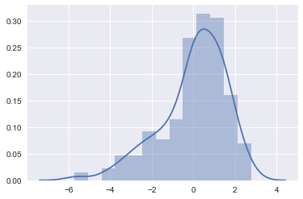

```python
sns.distplot(lm.resid)
```

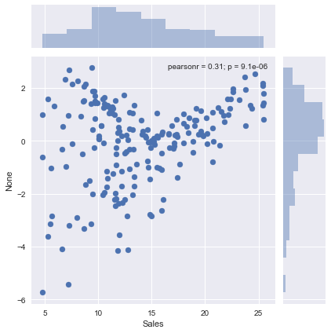

```python
sns.jointplot(  advt.Sales, lm.resid )
```

### USING sklearn Library to build the model

> sklearn library has a comprehensive set of APIs to split datasets, build models, test models and calculate accuracy metrics

```python
from sklearn.linear_model import LinearRegression
```

```python
# Splitting into Train and test data sets
# Typically the model should be built on a training dataset and validated against a test dataset
# Let's split the dataset into 70/30 ratio. 70% belongs to training and 30% belongs to test.

from sklearn.cross_validation import train_test_split
```

```python
X_train, X_test, y_train, y_test = train_test_split(
  advt[["TV", "Radio", "Newspaper"]],
  advt.Sales,
  test_size=0.3,
  random_state = 42 )
```

```python
print len( X_train )
print len( X_test)
```

```
140
60
```

```python
## Building the model with train set and make predictions on test set
linreg = LinearRegression()
linreg.fit( X_train, y_train )
y_pred = linreg.predict( X_test )
```

```python
linreg.coef_
```

```
array([ 0.04405928,  0.1992875 ,  0.00688245])
```

```python
from sklearn import metrics
rmse = np.sqrt( metrics.mean_squared_error( y_test, y_pred ) )
rmse
```

```
1.9485372043446387
```

```python
y_pred_t = linreg.predict(X_train)
rmse_t = np.sqrt( metrics.mean_squared_error( y_train, y_pred_t) )
rmse_t
```

```
1.574596830590544
```

```python
metrics.r2_score( y_train, y_pred_t )
```

```
0.90551595022277531
```

```python
metrics.r2_score( y_test, y_pred )
```

```
0.86094665082303679
```

```python
list( zip( ["TV", "Radio", "Newspaper"], list( linreg.coef_ ) ) )
```

```
[('TV', 0.044059280957465197),
 ('Radio', 0.19928749689893954),
 ('Newspaper', 0.0068824522222754557)]
```

```python
residuals = y_test - y_pred
```

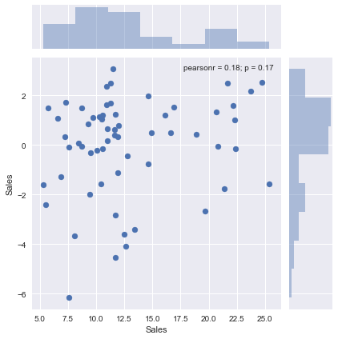

```python
sns.jointplot(  advt.Sales, residuals )
```

```python
sns.distplot( residuals )
```

[output not shown]

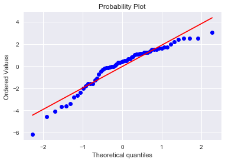

```python
# To ensure residues are random i.e. normally distributed a Q-Q plot can be used
# Q-Q plot shows if the residuals are plotted along the line.
from scipy import stats
import pylab

stats.probplot( residuals, dist="norm", plot=pylab )
pylab.show()
```

```python
### K-FOLD CROSS VALIDATION
from sklearn.cross_validation import cross_val_score
```

```python
linreg = LinearRegression()
```

```python
cross_val_score( linreg, X_train, y_train, scoring = 'r2', cv = 10 )
```

[output not shown]

```python
round( np.mean( cross_val_score( linreg,
                              X_train,
                              y_train,
                              scoring = 'r2',
                              cv = 10 ) ), 2 )
```

[output not shown]

```python
# Feature Selection based on importance
from sklearn.feature_selection import f_regression
```

```python
F_values, p_values  = f_regression(  X_train, y_train )
```

```python
F_values
```

[output not shown]

```python
['%.3f' % p for p in p_values]
```

[output not shown]

```python
### Exporting and importing the model
import pickle
```

```python
from sklearn.externals import joblib
joblib.dump(linreg, 'lin_model.pkl', compress=9)
```

[output not shown]

```python
model_clone = joblib.load('lin_model.pkl')
```